# Lipsticks

### Business Problem

hema is a frequent online shopper who regularly purchases cosmetic products, especially lipsticks, from e-commerce platforms. While browsing lipsticks on Amazon, she notices that prices vary significantly across brands, shades, and product types—even when the products appear similar in quality and usage.

For similar lipstick products, Ananya observes cases where:

- One brand offers a lipstick for around ₹150
- Another brand prices a similar lipstick above ₹1,000
- Some lipsticks with high discounts still receive good customer ratings
- Certain premium-priced lipsticks have ratings similar to budget products
- The same brand offers multiple lipsticks at different price points
- Discount percentages vary widely across products

These observations raise several questions in hema’s mind:

- Why do lipstick prices vary so much across brands?
- Does a higher price always indicate better quality or higher ratings?
- Are discounted lipsticks good value for money?
- Which brands offer the best balance between price and customer satisfaction?
- How do pricing strategies differ between budget, mid-range, and premium brands?
- These questions are relevant not only for individual customers like Ananya, but also for cosmetic brands and sellers who compete in a highly saturated and price-sensitive market. Understanding these pricing patterns can help both consumers make informed purchase decisions and businesses optimize their pricing strategies.

## Business Problem Statement

Lipstick prices on e-commerce platforms are influenced by multiple factors such as brand positioning, product weight, shade variety, discounts, and customer ratings. This creates uncertainty for customers who want to identify the best value-for-money products and for businesses aiming to understand competitive pricing behavior. To reduce ambiguity and uncover meaningful pricing insights, this project applies Exploratory Data Analysis (EDA) to:

- Compare lipstick prices across different brands
- Analyze the relationship between price, discounts, and customer ratings
- Identify budget, mid-range, premium, and luxury lipstick segments
- valuate how discounts impact customer perception
- Determine brands and products that offer the best value for money

The insights derived from this analysis can support smarter consumer choices and provide actionable business intelligence for cosmetic retailers and brands.

```python
from selenium import webdriver                      #to create a bridge between chrome and jupyter
from selenium.webdriver.chrome.service import Service  #if we want some servce from the chrome browser like installing of driver manager
from selenium.webdriver.chrome.options import Options   #options likem disable notifications and other functionality
from selenium.webdriver.common.by import By           #used to find the elements
from selenium.webdriver.common.keys import Keys        #keys is used to search something or to perform the clicks
from webdriver_manager.chrome import ChromeDriverManager    # install driver manager which will connect with your browser
import time                                     #to set a time delay because dyna,mic websites takes time to load the content
import pandas as pd
import re
```

```python
option = Options()
option.add_argument('--start-maximized') #== HEadless
service= Service(ChromeDriverManager().install())
```

```python
driver= webdriver.Chrome(service=service,options=option)
```

```python
url  = "https://www.amazon.in/s?k=lipsticks&page={page}"
url
```

```
'https://www.amazon.in/s?k=lipsticks&page={page}'
```

```python
driver.get(url)
```

```python
a = driver.find_elements(
    By.CSS_SELECTOR,
    ".a-size-base-plus.a-spacing-none.a-color-base.a-text-normal"
)[0].text
print(a)
```

```
SUGAR Cosmetics Glide Peptide Serum Lipstick with Hyaluronic Acid & Vitamin E | Velvet Matte Finish | Long Lasting & Pigmented | 1 Swipe Full Coverage | 4.2gm - 02 Positano Peach
```

```python
Brand_Names = []

pattern = r'^([A-Za-z0-9]+(?:\s[A-Za-z0-9]+){0,2})'

for i in range(1, 8):
    print(f"Scraping Page {i}")
    url = f"https://www.amazon.in/s?k=lipstick&page={i}"
    driver.get(url)
    time.sleep(4)

    brand_elements = driver.find_elements(
        By.CSS_SELECTOR,
        ".a-size-base-plus.a-spacing-none.a-color-base.a-text-normal"
    )

    for brand in brand_elements:
        text = brand.text.strip()
        if text:
            match = re.match(pattern, text)
            if match:
                Brand_Names.append(match.group(1))
```

```
Scraping Page 1
Scraping Page 2
Scraping Page 3
Scraping Page 4
Scraping Page 5
Scraping Page 6
Scraping Page 7
```

```python
len(Brand_Names)
```

```
445
```

```python
Weights = []

weight_pattern = r'(\d+(?:\.\d+)?\s?gm)'

for i in range(1, 8):
    print(f"Scraping Page {i}")
    url = f"https://www.amazon.in/s?k=lipstick&page={i}"
    driver.get(url)
    time.sleep(4)

    title_elements = driver.find_elements(
        By.CSS_SELECTOR,
        ".a-size-base-plus.a-spacing-none.a-color-base.a-text-normal"
    )

    for t in title_elements:
        text = t.text.strip()
        if not text:
            continue

        match = re.search(weight_pattern, text, re.IGNORECASE)
        if match:
            Weights.append(match.group(1))
        else:
            Weights.append(None)
```

```
Scraping Page 1
Scraping Page 2
Scraping Page 3
Scraping Page 4
Scraping Page 5
Scraping Page 6
Scraping Page 7
```

```python
len(Weights)
```

```
449
```

```python
Shade_Names = []

shade_pattern = r'-\s*\d+\s*([A-Za-z ]+)$'

for i in range(1, 8):
    print(f"Scraping Page {i}")
    url = f"https://www.amazon.in/s?k=lipstick&page={i}"
    driver.get(url)
    time.sleep(4)

    title_elements = driver.find_elements(
        By.CSS_SELECTOR,
        ".a-size-base-plus.a-spacing-none.a-color-base.a-text-normal"
    )

    for t in title_elements:
        text = t.text.strip()
        if not text:
            continue

        match = re.search(shade_pattern, text)
        if match:
            Shade_Names.append(match.group(1).strip())
        else:
            Shade_Names.append(None)
```

```
Scraping Page 1
Scraping Page 2
Scraping Page 3
Scraping Page 4
Scraping Page 5
Scraping Page 6
Scraping Page 7
```

```python
len(Shade_Names)
```

```
445
```

```python
Prices = []

wait = WebDriverWait(driver, 10)

for i in range(1, 8):
    print(f"Scraping Page {i}")
    url = f"https://www.amazon.in/s?k=lipstick&page={i}"
    driver.get(url)

    wait.until(EC.presence_of_all_elements_located(
        (By.CSS_SELECTOR, "span.a-price-whole")
    ))

    price_elements = driver.find_elements(
        By.CSS_SELECTOR,
        "span.a-price-whole"
    )

    for price in price_elements:
        text = price.text.strip()
        Prices.append(text.replace(",", "") if text else None)

print(Prices[:10])
```

```
Scraping Page 1
Scraping Page 2
Scraping Page 3
Scraping Page 4
Scraping Page 5
Scraping Page 6
Scraping Page 7
['1055', '1043', None, '381', '172', '299', '99', '87', '176', '70']
```

```python
len(Prices)
```

```
496
```

```python
MRP = []

for page in range(1, 8):
    url = f"https://www.amazon.in/s?k=lipstick&page={page}"
    driver.get(url)
    time.sleep(2)

    mrp_elements = driver.find_elements(
        By.CLASS_NAME,
        "a-text-price"
    )

    for mrp in mrp_elements:
        text = mrp.text.strip()
        if text:
            MRP.append(text.replace("₹", "").replace(",", ""))
```

```python
len(MRP)
```

```
420
```

```python
Rating = []

for page in range(1, 8):
    url = f"https://www.amazon.in/s?k=lipstick&page={page}"
    driver.get(url)
    time.sleep(2)

    mrp_elements = driver.find_elements(
        By.CLASS_NAME,
        "a-size-small.a-color-base"
    )

    for mrp in mrp_elements:
        text = mrp.text.strip()
        if text:
            Rating.append(text)
```

```python
len(Rating)
```

```
459
```

```python
min_len = min(
    len(Brand_Names),
    len(Weights),
    len(Shade_Names),
    len(Prices),
    len(MRP),
    len(Rating)
)
```

```python
min_len
```

```
420
```

```python
min_len = min(len(df), len(Weights))
df = df.iloc[:min_len].copy()
df['Weight'] = Weights[:min_len]
```

```python
df = pd.DataFrame({
    "Brand Name": Brand_Names[:min_len],
    "Weight": Weights[:min_len],
    "Shade Name": Shade_Names[:min_len],
    "Selling Price": Prices[:min_len],
    "MRP": MRP[:min_len],
    "Rating": Rating[:min_len]
})

df
```

```python
df.info()
```

[output not shown]

```python
df.to_csv('lipstick.csv')
```

```python
df
```

|  | Brand Name | Weight | Shade Name | Selling Price | MRP | Rating |
| --- | --- | --- | --- | --- | --- | --- |
| 0 | SUGAR Cosmetics Glide | 3.8 g | Moscow Mulberry | 1055 | 499 | 4.4 |
| 1 | Swiss Beauty Pure | 4.5 g | Caramel Nude | 1043 | 229 | 4.0 |
| 2 | Maybelline New York | 3.5 g | Burnt Orange | 239 | 399 | 4.1 |
| 3 | Swiss Beauty Hd | 3.2 g | Burnt Orange | 381 | 329 | 3.9 |
| 4 | Blue Heaven Get | 5 ml | Rose Nude | 172 | 99 | 4.1 |
| ... | ... | ... | ... | ... | ... | ... |
| 415 | Swiss Beauty Pure | 3.8 g | Nude Nuance | 248 | 299 | 3.9 |
| 416 | L | 5 g | Blush Pink | 338 | 499 | 4.4 |
| 417 | STREET WEAR Satin | 6 ml | Berry Blast | 539 | 650 | 4.0 |
| 418 | FASHION COLOUR Velvet | 2.5 g | Brandy Harrington | 442 | 299 | 4.0 |
| 419 | MILA BEAUT | 6 ml | Ruby Red | 314 | 349 | 4.1 |

420 rows × 6 columns

### Changing the column Datatypes

```python
df.dtypes
```

[output not shown]

```python
df.to_csv("lipstick_dataset_final.csv", index=False)
```

```python
df["Discount_Amount"] = df["MRP"] - df["Selling Price"]
```

```python
df.dtypes
```

[output not shown]

## Data cleaning

```python
df
```

|  | Brand Name | Weight | Shade Name | Selling Price | MRP | Rating | Discount_Amount | Price_Category | Rating_Category | Shade_Intensity |
| --- | --- | --- | --- | --- | --- | --- | --- | --- | --- | --- |
| 0 | SUGAR Cosmetics | 5.0 | Moscow Mulberry | 1055 | 499 | 4.4 | 556 | Luxury | Very Good | Heavy Shade |
| 1 | Swiss Beauty | 3.2 | Caramel Nude | 1043 | 229 | 4.0 | 814 | Luxury | Good | Light Shade |
| 2 | Maybelline New York | 4.0 | Burnt Orange | 239 | 399 | 4.1 | 160 | Mid-Range | Good | Medium Shade |
| 3 | Swiss Beauty | 4.2 | Burnt Orange | 381 | 329 | 3.9 | 52 | Mid-Range | Average | Medium Shade |
| 4 | Blue Heaven | 3.2 | Rose Nude | 172 | 99 | 4.1 | 73 | Budget | Good | Light Shade |
| ... | ... | ... | ... | ... | ... | ... | ... | ... | ... | ... |
| 415 | Swiss Beauty | 4.0 | Nude Nuance | 248 | 299 | 3.9 | 51 | Mid-Range | Average | Light Shade |
| 416 | Lakme | 5.0 | Blush Pink | 338 | 499 | 4.4 | 161 | Mid-Range | Very Good | Light Shade |
| 417 | STREET WEAR Satin | 5.0 | Berry Blast | 539 | 650 | 4.0 | 111 | Premium | Good | Heavy Shade |
| 418 | FASHION COLOUR Velvet | 2.5 | Brandy Harrington | 442 | 299 | 4.0 | 143 | Mid-Range | Good | Medium Shade |
| 419 | MILA BEAUT | 6.0 | Ruby Red | 314 | 349 | 4.1 | 35 | Mid-Range | Good | Heavy Shade |

420 rows × 10 columns

### Filling Null Values

```python
df.isna().sum()
```

```
Brand Name             0
Weight                 0
Shade Name             0
Selling Price          0
MRP                    0
Rating                 0
Discount_Amount        0
Price_Category         0
Rating_Category        0
Shade_Intensity        0
Discount_Amount_Abs    0
dtype: int64
```

```python
mode= df['Rating'].mode()[0]
```

```python
mode
```

```
np.float64(4.0)
```

```python
df['Rating'] = df['Rating'].fillna(mode)
```

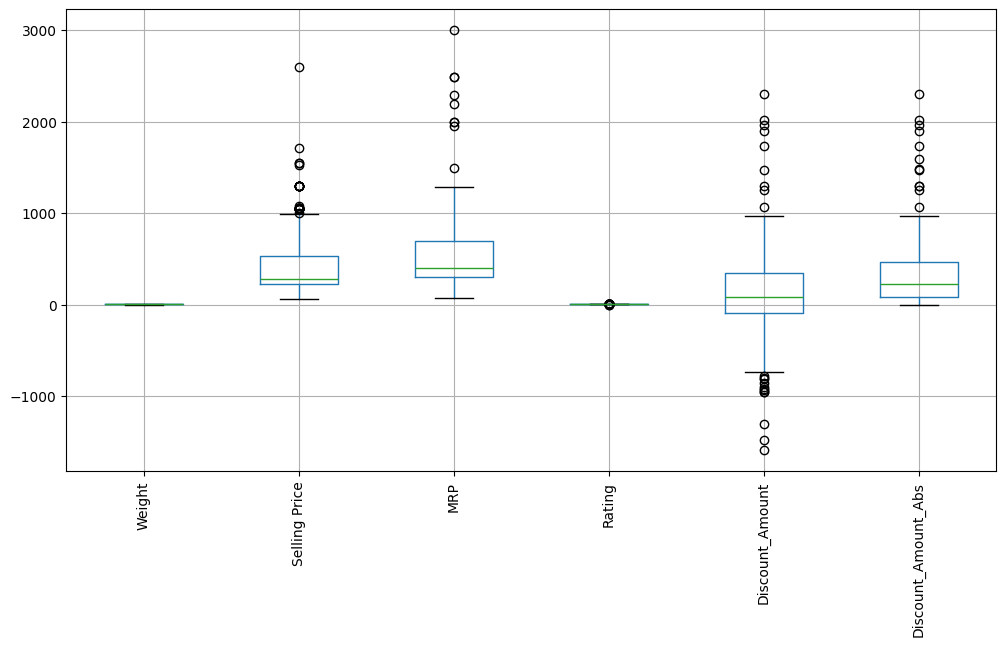

```python
import matplotlib.pyplot as plt

df.select_dtypes(include='number').boxplot(figsize=(12,6))
plt.xticks(rotation=90)
plt.show()
```

- Using the box plot visualization, it was observed that the Discount Amount column contains negative values.
- This indicates that, for some products, the calculated discount resulted in negative numbers due to price inconsistencies.

### Converting negative values to positive

```python
df["Discount_Amount"] = (df["MRP"] - df["Selling Price"]).abs()
```

```python
df
```

|  | Brand Name | Weight | Shade Name | Selling Price | MRP | Rating | Discount_Amount | Price_Category | Rating_Category | Shade_Intensity |
| --- | --- | --- | --- | --- | --- | --- | --- | --- | --- | --- |
| 0 | SUGAR Cosmetics | 5.0 | Moscow Mulberry | 1055 | 499 | 4.4 | 556 | Luxury | Very Good | Heavy Shade |
| 1 | Swiss Beauty | 3.2 | Caramel Nude | 1043 | 229 | 4.0 | 814 | Luxury | Good | Light Shade |
| 2 | Maybelline New York | 4.0 | Burnt Orange | 239 | 399 | 4.1 | 160 | Mid-Range | Good | Medium Shade |
| 3 | Swiss Beauty | 4.2 | Burnt Orange | 381 | 329 | 3.9 | 52 | Mid-Range | Average | Medium Shade |
| 4 | Blue Heaven | 3.2 | Rose Nude | 172 | 99 | 4.1 | 73 | Budget | Good | Light Shade |
| ... | ... | ... | ... | ... | ... | ... | ... | ... | ... | ... |
| 415 | Swiss Beauty | 4.0 | Nude Nuance | 248 | 299 | 3.9 | 51 | Mid-Range | Average | Light Shade |
| 416 | Lakme | 5.0 | Blush Pink | 338 | 499 | 4.4 | 161 | Mid-Range | Very Good | Light Shade |
| 417 | STREET WEAR Satin | 5.0 | Berry Blast | 539 | 650 | 4.0 | 111 | Premium | Good | Heavy Shade |
| 418 | FASHION COLOUR Velvet | 2.5 | Brandy Harrington | 442 | 299 | 4.0 | 143 | Mid-Range | Good | Medium Shade |
| 419 | MILA BEAUT | 6.0 | Ruby Red | 314 | 349 | 4.1 | 35 | Mid-Range | Good | Heavy Shade |

420 rows × 10 columns

```python
df.drop(columns="Discount_Amount_Abs",inplace = True)
```

```python
df.to_csv('lipstick_hema.csv')
```

```python
import pandas as pd
import seaborn as sns
import matplotlib.pyplot as plt
```

```python
df = pd.read_csv(r"C:\Users\chink\OneDrive\Desktop\lipstick_hema.csv")
```

```python
df
```

|  | Unnamed: 0 | Brand Name | Weight | Shade Name | Selling Price | MRP | Rating | Discount_Amount | Price_Category | Rating_Category | Shade_Intensity |
| --- | --- | --- | --- | --- | --- | --- | --- | --- | --- | --- | --- |
| 0 | 0 | SUGAR Cosmetics | 5.0 | Moscow Mulberry | 1055 | 499 | 4.4 | 556 | Luxury | Very Good | Heavy Shade |
| 1 | 1 | Swiss Beauty | 3.2 | Caramel Nude | 1043 | 229 | 4.0 | 814 | Luxury | Good | Light Shade |
| 2 | 2 | Maybelline New York | 4.0 | Burnt Orange | 239 | 399 | 4.1 | 160 | Mid-Range | Good | Medium Shade |
| 3 | 3 | Swiss Beauty | 4.2 | Burnt Orange | 381 | 329 | 3.9 | 52 | Mid-Range | Average | Medium Shade |
| 4 | 4 | Blue Heaven | 3.2 | Rose Nude | 172 | 99 | 4.1 | 73 | Budget | Good | Light Shade |
| ... | ... | ... | ... | ... | ... | ... | ... | ... | ... | ... | ... |
| 415 | 415 | Swiss Beauty | 4.0 | Nude Nuance | 248 | 299 | 3.9 | 51 | Mid-Range | Average | Light Shade |
| 416 | 416 | Lakme | 5.0 | Blush Pink | 338 | 499 | 4.4 | 161 | Mid-Range | Very Good | Light Shade |
| 417 | 417 | STREET WEAR Satin | 5.0 | Berry Blast | 539 | 650 | 4.0 | 111 | Premium | Good | Heavy Shade |
| 418 | 418 | FASHION COLOUR Velvet | 2.5 | Brandy Harrington | 442 | 299 | 4.0 | 143 | Mid-Range | Good | Medium Shade |
| 419 | 419 | MILA BEAUT | 6.0 | Ruby Red | 314 | 349 | 4.1 | 35 | Mid-Range | Good | Heavy Shade |

420 rows × 11 columns

### UNIVARIATE ANALYSIS`

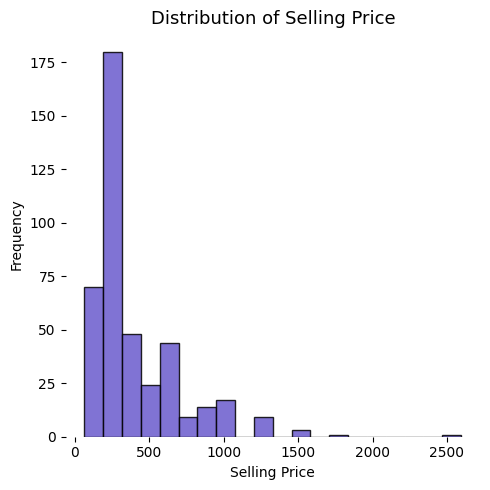

```python
plt.figure(figsize=(5, 5))

plt.hist(
    df["Selling Price"],
    bins=20,
    color="#6A5ACD",
    edgecolor="black",
    alpha=0.85
)

plt.title("Distribution of Selling Price", fontsize=13)
plt.xlabel("Selling Price")
plt.ylabel("Frequency")


plt.grid(False)
plt.box(False)

plt.tight_layout()
plt.show()
```

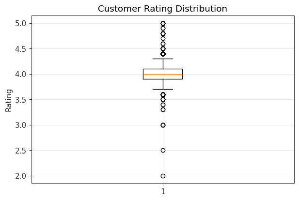

```python
plt.figure()
plt.boxplot(df["Rating"], vert=True)
plt.title("Customer Rating Distribution")
plt.ylabel("Rating")
plt.show()
```

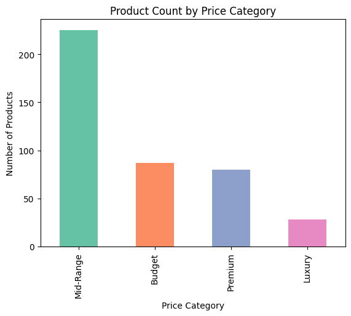

```python
import matplotlib.pyplot as plt

plt.figure()
df["Price_Category"].value_counts().plot(
    kind="bar",
    color=plt.cm.Set2.colors
)
plt.title("Product Count by Price Category")
plt.xlabel("Price Category")
plt.ylabel("Number of Products")
plt.show()
```

### BIVARIATE ANALYSIS

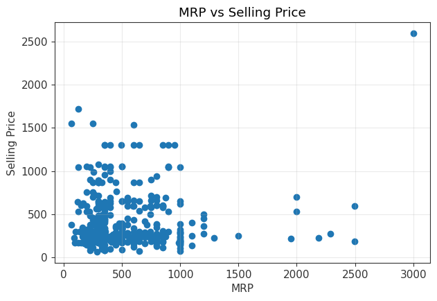

```python
plt.figure()
plt.scatter(df["MRP"], df["Selling Price"])
plt.title("MRP vs Selling Price")
plt.xlabel("MRP")
plt.ylabel("Selling Price")
plt.show()
```

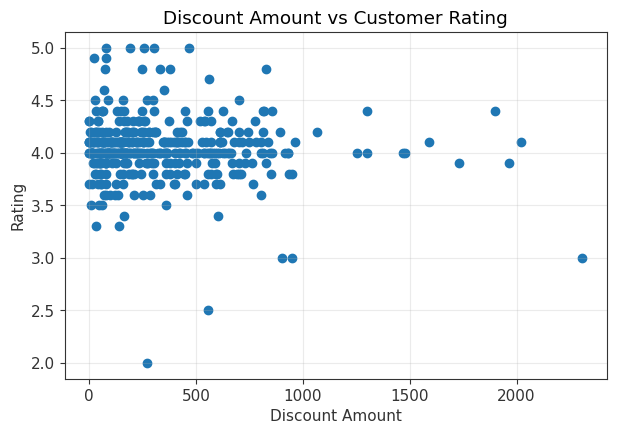

```python
plt.figure()
plt.scatter(df["Discount_Amount"], df["Rating"])
plt.title("Discount Amount vs Customer Rating")
plt.xlabel("Discount Amount")
plt.ylabel("Rating")
plt.show()
```

### **Key Insight:**

- Customer ratings remain largely stable across different discount amounts, clustering around 3.8–4.2.
- Higher discounts do not guarantee better ratings, indicating product quality matters more than discount size.

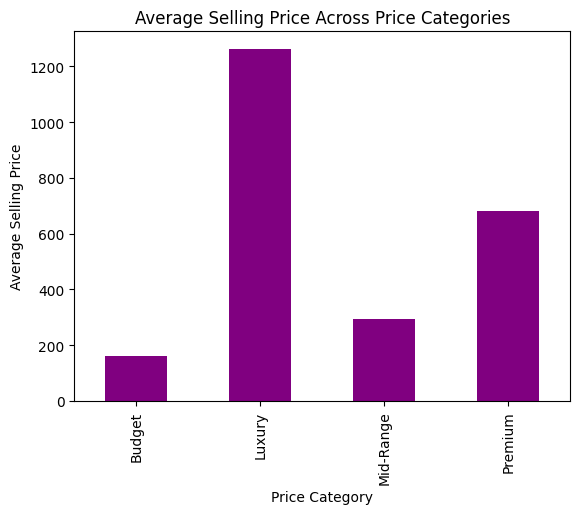

```python
plt.figure()

df.groupby("Price_Category")["Selling Price"].mean().plot(kind="bar", color= "purple")

plt.title("Average Selling Price Across Price Categories")
plt.xlabel("Price Category")
plt.ylabel("Average Selling Price")

plt.show()
```

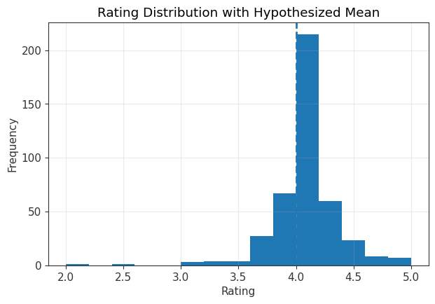

```python
plt.figure()

plt.hist(df["Rating"], bins=15)
plt.axvline(4.0, linestyle="--", linewidth=2)

plt.title("Rating Distribution with Hypothesized Mean")
plt.xlabel("Rating")
plt.ylabel("Frequency")

plt.show()
```

### Hypothesis 1 — One Way ANOVA

### Question: Do average product ratings differ across different price categories?

Null Hypothesis (H0): All price categories have equal mean ratings

Alternate Hypothesis (H1): At least one price category has a different mean rating

```
Reject Null Hypothesis. i.e There is relationship between variables
```

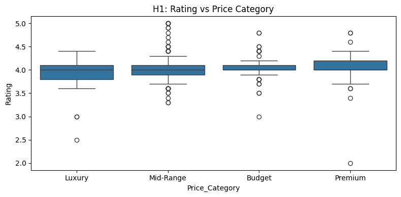

```python
from scipy.stats import f_oneway
import seaborn as sns
import matplotlib.pyplot as plt

groups = []
for cat in df['Price_Category'].unique():
    groups.append(df[df['Price_Category'] == cat]['Rating'].values)

stat, p_value = f_oneway(*groups)

cl = 0.95
alpha = 1 - cl

if p_value <= alpha:
    print("Reject Null Hypothesis. i.e There is relationship between variables")
else:
    print("Failed to reject Null Hypothesis. i.e There is no relationship between variables")

plt.figure(figsize=(8,4))
sns.boxplot(x='Price_Category', y='Rating', data=df)
plt.title('H1: Rating vs Price Category')
plt.tight_layout()
plt.show()
```

### Hypothesis 2 (Chi-Square)

**Question:** Is shade intensity dependent on price category?

- Null Hypothesis (H0): Shade intensity is independent of price category
- Alternate Hypothesis (H1): Shade intensity is dependent on price category

```
Failed to reject Null Hypothesis. i.e There is no relationship between variables
```

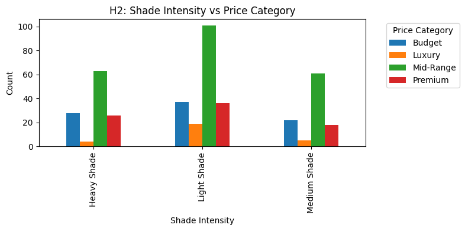

```python
from scipy.stats import chi2_contingency

ct = pd.crosstab(df['Shade_Intensity'], df['Price_Category'])
stat, p_value, dof, exp = chi2_contingency(ct)

cl = 0.95
alpha = 1 - cl

if p_value <= alpha:
    print("Reject Null Hypothesis. i.e There is relationship between variables")
else:
    print("Failed to reject Null Hypothesis. i.e There is no relationship between variables")

ct.plot(kind='bar', figsize=(8,4))
plt.title('H2: Shade Intensity vs Price Category')
plt.xlabel('Shade Intensity')
plt.ylabel('Count')
plt.legend(title='Price Category', bbox_to_anchor=(1.05, 1), loc='upper left')
plt.tight_layout()
plt.show()
```

**Key Insight:** Shade intensity distribution appears similar across price categories, with no clear dominance of specific shades in Budget, Premium, or Luxury segments. Both the χ² test and the barplot indicate no meaningful association between price category and shade intensity. Shade preferences seem broadly consistent regardless of price tier.

### Hypothesis 3 (T-Test)

**Question:** Does discount level influence product rating?

- Null Hypothesis (H0): Mean rating is the same for high-discount and low-discount products
- Alternate Hypothesis (H1): Mean rating differs between high-discount and low-discount products

```python
from scipy.stats import ttest_ind
```

```
Failed to reject Null Hypothesis. i.e There is no relationship between variables
```

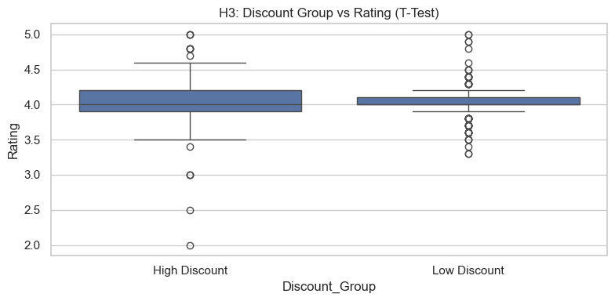

```python
median_discount = df['Discount_Amount'].median()

df['Discount_Group'] = df['Discount_Amount'].apply(
    lambda x: 'High Discount' if x >= median_discount else 'Low Discount'
)

high = df[df['Discount_Group'] == 'High Discount']['Rating']
low = df[df['Discount_Group'] == 'Low Discount']['Rating']

stat, p_value = ttest_ind(high, low, equal_var=False)

cl = 0.95
alpha = 1 - cl

if p_value <= alpha:
    print("Reject Null Hypothesis. i.e There is relationship between variables")
else:
    print("Failed to reject Null Hypothesis. i.e There is no relationship between variables")

plt.figure(figsize=(8,4))
sns.set(style='whitegrid')
sns.boxplot(x='Discount_Group', y='Rating', data=df)
plt.title('H3: Discount Group vs Rating (T-Test)')
plt.tight_layout()
plt.show()
```

**Key Insight :** The T-test shows no significant difference in ratings between high-discount and low-discount products. Both groups cluster around similar median ratings in the boxplot, indicating that deeper discounts do not improve customer rating sentiment for lipsticks in this dataset.

# Conclusion

## Bivariate + Multivariate EDA — Key Learnings

### 1. Rating Distribution

Ratings are highly concentrated between 3.5 and 4.5, with a mean near 4.0.

**Interpretation:**  
Products are generally well-received; negative ratings are rare.

### 2. Price Category vs Average Selling Price

Premium and Luxury categories command higher selling prices, with clear price stratification.

**Interpretation:**  
Pricing strategy is structured and market-position driven.

### 3. Discount Amount vs Rating

Scatterplot shows overlapping clusters with no upward trend.

**Interpretation:**  
Discounts drive conversions, not sentiment; reviews remain stable.

## Hypothesis Validation (EDA → Statistics)

EDA insights were validated statistically:

- **H1 (Price Category vs Rating — ANOVA):** Reject H0 (Significant)
- **H2 (Shade vs Price Category — Chi-Square):** Fail to Reject H0 (Not Significant)
- **H3 (Discount vs Rating — T-Test):** Fail to Reject H0 (Not Significant)

## Interpretation

Visual patterns were consistent with statistical outcomes.  
Although price category affects ratings, the practical effect is modest due to clustered medians.  
Shade and discount strategies do not modify customer perception or review behavior.

## Recommendations

- Compete on product experience and brand value over aggressive discounting.
- Use discounts to boost sales volume, not review scores.
- Expand inclusive shade ranges rather than pricing-based segmentation.
- Maintain consistent formulation quality across price tiers.
- Reinforce premium tiers through branding rather than discount manipulation.

## Final Conclusion

Lipsticks exhibit structured pricing tiers and high consumer satisfaction across categories.  
Statistical testing confirms that price tier impacts ratings, but differences are small in practice.  
Shade intensity and discounting do not influence rating sentiment, indicating that cosmetic consumers evaluate based on product performance and shade fit rather than monetization strategies.